# Asymptotic Statistics 5.8 Rates of Convergence

Author

March

Published

March 11, 2026

$$\newcommand{\E}{\mathrm{E}}
\newcommand{\G}{\mathbb{G}}
\newcommand{\P}{\mathbb{P}}
\newcommand{\R}{\mathbb{R}}
\newcommand{\Pr}{\mathrm{Pr}}
\newcommand{\smallop}[1][1]{o_{\mathrm{p}}\left(#1\right)}
\newcommand{\largeop}[1][1]{O_{\mathrm{p}}\left(#1\right)}$$

## 5.8 Rates of Convergence

- $(\Theta,d)$ は可分距離空間，$(\mathfrak{X},\mathscr{A})$ は可測空間とする．
- 確率空間 $(\Omega,\mathscr{B},\Pr)$ 上の可測写像 $X_1,\dots,X_n\colon\Omega\to\mathfrak{X}$ は独立に同分布 $P$ に従うとする．
- $P(\{x\in\mathfrak{X}\mid \theta\mapsto m_{\theta}(x)\text{ は連続}\})=1$ とする．

**Remark**

$(\Theta,d)$ の可分性，$\theta\mapsto m_\theta$ の連続性は $\sup_{d(\theta,\theta_0)\leq\delta}|\G_n(m_\theta-m_{\theta_0})|$ の可測性のために要請しているが，外測度を使うことでこの仮定は外せる．実際，Van der Vaart (1998) ではそのようにしている．

**Memo**

外測度つかった議論からは逃げようと思っていたのですが，Example 1 が可測性保証されないことと，外測度への拡張はそこまで難しくなかったのでちゃんと向き合いました． 例えば，分類問題の損失として $m_\theta(x,y)=1\{f_\theta(x)=y\}$ を用いて，$f_\theta$ をニューラルネットワークでモデリングするみたいなことをすると途端に可測性は破綻するので外測度に向き合うのは大事かもしれません．

**Theorem 1 (Van der Vaart (1998) Theorem 5.52)** 以下を満たすような定数 $C,\Delta>0$ と $\alpha>\beta>0$，および $\theta_0\in\Theta$ が存在することを仮定する．

任意の $n\in\mathbb{N}$ と $\delta\in(0,\Delta)$ に対し，
$$\begin{align}
\sup_{d(\theta,\theta_0)\in(\delta/2,\delta]}P(m_{\theta}-m_{\theta_0})\leq -C\delta^\alpha,\\
\E\left[\sup_{d(\theta,\theta_0)\leq\delta}\left|\G_n(m_{\theta}-m_{\theta_0})\right|\right]\leq C\delta^\beta.
\end{align}$$

このとき，$\P_nm_{\hat\theta_n}\geq\P_nm_{\theta_0}-\largeop[n^{\alpha/(2\beta-2\alpha)}]$ と $d(\hat\theta_n,\theta_0)=\smallop[1]$ を満たす推定量 $\hat\theta_n$ は次を満たす：
$$n^{1/(2\alpha-2\beta)}d(\hat\theta_n,\theta_0)=\largeop[1].$$

**Memo**

仮定の検証がつらいだけで，証明は行間にさえ目をつむればそこまでつらくない． 証明のポイントは評価したい集合を手元の道具が使える形にばらすこと．

*Proof*. $r_n\coloneqq n^{1/(2\alpha-2\beta)},R_n\coloneqq\largeop[r_n^{-\alpha}]$ とする．任意の $\epsilon>0$ に対し，ある $M>0$ が存在して，
$$\limsup_{n\to\infty}\Pr\left(r_nd(\hat\theta_n,\theta_0)>2^M\right)<\epsilon$$

となることを示せばよい．$A_n\coloneqq\{\omega\in\Omega\mid r_nd(\hat\theta_n(\omega),\theta_0)>2^M\}$ とすると，任意の $K>0$ と $\varepsilon>0$ に対して，
$$\begin{align*}
A_n&\subset B_n\cup\left\{2d(\hat\theta_n,\theta_0)\geq\varepsilon\right\}\cup\left\{r_n^\alpha R_n\geq K\right\}\\
B_n&\coloneqq A_n\cap\left\{2d(\hat\theta_n,\theta_0)<\varepsilon\right\}\cap\left\{r_n^\alpha R_n<K\right\}\\
&=\left\{r_nd(\hat\theta_n,\theta_0)\in(2^M,r_n\varepsilon/2),r_n^\alpha R_n<K\right\}
\end{align*}$$

である．

**Memo**

$A_n$ を扱いやすい形にばらしたい．2つ目の項は推定量の一致性が使えそう．3つ目の項は $r_n^\alpha R_n$ が確率有界であることが使えそう．$B_n$ はまだ扱いづらい形をしているが，これから頑張る．

$j\in\mathbb{Z}$ に対して，$S_{j,n}\coloneqq\{\theta\in\Theta\mid r_nd(\theta,\theta_0)\in(2^{j-1},2^j]\}$ とする．このとき，$d(\hat\theta_n(\omega),\theta_0)\in(2^M,r_n\varepsilon/2)$ ならば，ある $j\in[M,\log_2(r_n\varepsilon))$ が存在して，$\hat\theta_n(\omega)\in S_{j,n}$ である．

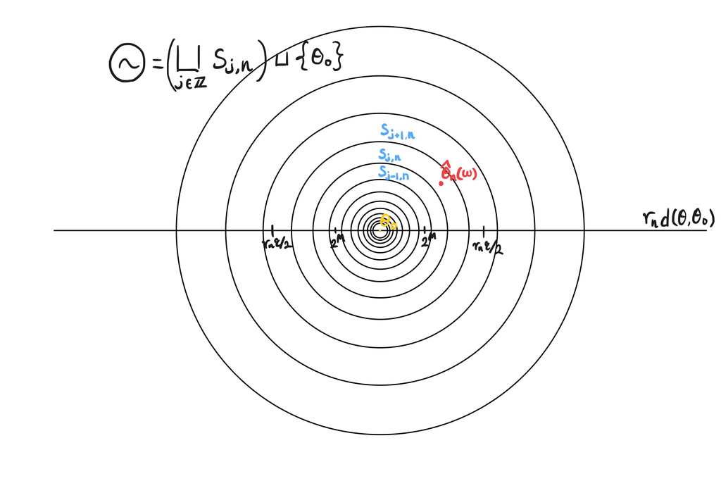

$S_{j,n}$ と $\hat\theta_n(\omega)$ の関係

**Note**

このように，$\theta_0$ を中心として，皮を一枚ずつ剥いていくように空間を分割する操作を剝ぎ取り技法 (Peeling device) というらしい．

したがって，

$$\begin{align*}
B_n&\subset\left\{\omega\,\middle|\, \hat\theta_n(\omega)\in S_{j,n},\enspace\exists j\in[M,\log_2(r_n\varepsilon)),\enspace r_n^\alpha R_n(\omega)<K\right\}\\
&\subset\bigcup_{j\in[M,\log_2(r_n\varepsilon))\cap\mathbb{Z}}\left\{\omega\,\middle|\,\hat\theta_n(\omega)\in S_{j,n},r_n^\alpha R_n(\omega)<K\right\}
\end{align*}$$

である．さらに，$\P_n(m_{\hat\theta_n}-m_{\theta_0})\geq-R_n$ より，$\hat\theta_n(\omega)\in S_{j,n}$ ならば，
$$\sup_{\theta\in S_{j,n}}\P_n\left(m_{\theta}-m_{\theta_0}\right)\geq-R_n$$

である．よって，$\P_n=P+n^{-1/2}\G_n$ に注意すると，
$$\begin{align*}
B_n&\subset\bigcup_{j\in[M,\log_2(r_n\varepsilon))\cap\mathbb{Z}}\left\{
\sup_{\theta\in S_{j,n}}\P_n\left(m_{\theta}-m_{\theta_0}\right)>-\frac{K}{r_n^\alpha}
\right\}\\
&\subset\bigcup_{j\in[M,\log_2(r_n\varepsilon))\cap\mathbb{Z}}\left\{
\sup_{\theta\in S_{j,n}}P\left(m_{\theta}-m_{\theta_0}\right)+
n^{-1/2}\sup_{\theta\in S_{j,n}}\left|\G_n\left(m_{\theta}-m_{\theta_0}\right)\right|>-\frac{K}{r_n^\alpha}
\right\}
\end{align*}$$

である．

**Memo**

経験過程で殴れそうな形になってきた．ここから，仮定を使いにいく．

$\varepsilon<\Delta$ となるように，$\varepsilon$ を十分小さくとる． $j\in[M,\log_2(r_n\varepsilon))$ について，1つ目の仮定に $\delta=2^j/r_n<\varepsilon<\Delta$ を代入すると，
$$\sup_{\theta\in S_{j,n}}P(m_\theta-m_{\theta_0})\leq -C\frac{2^{j\alpha}}{r_n^\alpha}$$

が得られる．特に $K\leq C2^{M\alpha-1}$ については，$j\in[M,\log_2(r_n\varepsilon))$ に対して，$K\leq C2^{M\alpha-1}\leq C2^{j\alpha-1}$ も成り立っていることに注意すると，
$$\begin{align*}
B_n&\subset\bigcup_{j\in[M,\log_2(r_n\varepsilon))\cap\mathbb{Z}}\left\{
n^{-1/2}\sup_{\theta\in S_{j,n}}\left|\G_n\left(m_{\theta}-m_{\theta_0}\right)\right|>C\frac{2^{j\alpha}}{r_n^\alpha}-\frac{K}{r_n^\alpha}
\right\}\\
&\subset\bigcup_{j\in[M,\log_2(r_n\varepsilon))\cap\mathbb{Z}}\left\{
n^{-1/2}\sup_{\theta\in S_{j,n}}\left|\G_n\left(m_{\theta}-m_{\theta_0}\right)\right|>C\frac{2^{j\alpha}}{r_n^\alpha}-C\frac{2^{j\alpha-1}}{r_n^\alpha}
\right\}\\
&\subset\bigcup_{j\in[M,\log_2(r_n\varepsilon))\cap\mathbb{Z}}
\left\{
\sup_{\theta\in S_{j,n}}\left|\G_n\left(m_{\theta}-m_{\theta_0}\right)\right|>\sqrt{n}C\frac{2^{j\alpha-1}}{r_n^\alpha}
\right\}
\end{align*}$$

が得られる．

最後に $\E[\sup_{\theta\in S_{j,n}}|\G_n(m_\theta-m_{\theta_0})|]$ の上界を評価する．2つ目の仮定に $\delta=2^j/r_n$ を代入すると，
$$\E\left[\sup_{\theta\in S_{j,n}}\left|\G_n(m_\theta-m_{\theta_0})\right|\right]
\leq\E\left[\sup_{r_nd(\theta,\theta_0)\leq2^j}\left|\G_n(m_\theta-m_{\theta_0})\right|\right]
\leq C\frac{2^{j\beta}}{r_n^\beta}$$

となる．

**Memo**

期待値の単調性を使った．外期待値にも単調性がある．Proposition 4 を参照．

以上より，Markov の不等式を使って，
$$\begin{align*}
\Pr(A_n)&\leq
\sum_{j\in[M,\log_2(r_n\varepsilon))\cap\mathbb{Z}}\Pr\left(
\sup_{\theta\in S_{j,n}}\left|\G_n\left(m_{\theta}-m_{\theta_0}\right)\right|>\sqrt{n}C\frac{2^{j\alpha-1}}{r_n^\alpha}
\right)\\
&\hphantom{=}+\Pr\left(2d(\hat\theta_n,\theta_0)\geq\varepsilon\right)+\Pr\left(r_n^\alpha R_n\geq K\right)\\
&\leq\sum_{j\in[M,\log_2(r_n\varepsilon))\cap\mathbb{Z}}\E\left[
\sup_{\theta\in S_{j,n}}\left|\G_n\left(m_{\theta}-m_{\theta_0}\right)\right|\right]n^{-1/2}\frac{r_n^\alpha}{C2^{j\alpha-1}}\\
&\hphantom{=}+\Pr\left(2d(\hat\theta_n,\theta_0)\geq\varepsilon\right)+\Pr\left(r_n^\alpha R_n\geq K\right)\\
&\leq\sum_{j\in[M,\log_2(r_n\varepsilon))\cap\mathbb{Z}}
n^{-1/2}\frac{2^{j\beta}r_n^\alpha}{2^{j\alpha-1}r_n^{\beta}}+\Pr\left(2d(\hat\theta_n,\theta_0)\geq\varepsilon\right)+\Pr\left(r_n^\alpha R_n\geq K\right)\\
&\leq \cancel{n^{-1/2}r_n^{\alpha-\beta}}2\sum_{j\geq M}
2^{j(\beta-\alpha)}
+\Pr\left(2d(\hat\theta_n,\theta_0)\geq\varepsilon\right)+\Pr\left(r_n^\alpha R_n\geq K\right)
%&=2^{\alpha+1}\frac{2^{M(\beta-\alpha)}}{1-2^{\beta-\alpha}}+P\left(2d(\hat\theta_n,\theta_0)\geq\varepsilon\right)+P\left(r_n^\alpha R_n\geq K\right)
\end{align*}$$

**Memo**

確率の劣加法性と Markov の不等式を使った．外確率，外期待値の場合も問題なし．Proposition 5 と Proposition 6 を参照．

$\epsilon>0$ に対して，

1. $d(\hat\theta_n,\theta_0)=\smallop[1]$ より，$\limsup_{n\to\infty}\Pr(2d(\hat\theta_n,\theta_0)\geq\varepsilon)=0$ である．
2. $R_n=\largeop[r_n^{-\alpha}]$ より，ある $K$ が存在して，$\limsup_{n\to\infty}\Pr(r_n^\alpha R_n\geq K)<\epsilon/3$ とできる．
3. ある $K\leq C2^{M\alpha-1}$ を満たす $M>0$ が存在して，$2\sum_{j\geq M}2^{j(\beta-\alpha)}<\epsilon/3$ とできる．

よって，$\limsup_{n\to\infty}\Pr(A_n)<\epsilon$

**Proposition 1** 以下を満たすような定数 $C_1,C_2>0$ と $\alpha>\beta>0$ が存在することを仮定する．

任意の $\delta>0$ に対して，
$$\begin{align}
\sup_{d(\theta,\theta_0)\in(\delta/2,\delta]}P(m_{\theta}-m_{\theta_0})\leq -C_1\delta^\alpha,\\
\E\left[\sup_{d(\theta,\theta_0)\leq\delta}\left|\G_n(m_{\theta}-m_{\theta_0})\right|\right]\leq C_2\delta^\beta.
\end{align}$$

このとき，推定量 $\hat\theta_n\in\arg\max_{\theta\in\Theta}\P_nm_{\theta}$ は，任意の $M>0$ に対し，
$$\Pr\left(d(\hat\theta_n,\theta_0)>\frac{2^M}{n^{1/(2\alpha-2\beta)}}\right)\leq\frac{C_2}{C_1}\frac{2^{M(\beta-\alpha)}}{1-2^{\beta-\alpha}}$$

を満たす．

*Proof*. $j\in\mathbb{Z}$ に対して，$S_{j,n}\coloneqq\{\theta\in\Theta\mid r_nd(\theta,\theta_0)\in(2^{j-1},2^j]\}$ とする． $r_n\coloneqq n^{1/(2\alpha-2\beta)},A_n\coloneqq\{\omega\in\Omega\mid r_nd(\hat\theta_n(\omega),\theta_0)>2^M\}$ とすると，
$$\begin{align*}
A_n&\subset\left\{\omega\,\middle|\, \hat\theta_n(\omega)\in S_{j,n},\enspace \exists j\geq M+1\right\}\\
&\subset\bigcup_{j\geq M}\left\{\omega\,\middle|\, \hat\theta_n(\omega)\in S_{j,n}\right\}\\
\end{align*}$$

である． さらに，$\P_n(m_{\hat\theta_n}-m_{\theta_0})\geq0$ より，$\hat\theta_n(\omega)\in S_{j,n}$ ならば，
$$\sup_{\theta\in S_{j,n}}\P_n\left(m_{\theta}-m_{\theta_0}\right)\geq0$$

である．よって，$\P_n=P+n^{-1/2}\G_n$ に注意すると，
$$\begin{align*}
A_n&\subset\bigcup_{j\geq M}\left\{
\sup_{\theta\in S_{j,n}}\P_n\left(m_{\theta}-m_{\theta_0}\right)>0
\right\}\\
&\subset\bigcup_{j\geq M}\left\{
\sup_{\theta\in S_{j,n}}P\left(m_{\theta}-m_{\theta_0}\right)+
n^{-1/2}\sup_{\theta\in S_{j,n}}\left|\G_n\left(m_{\theta}-m_{\theta_0}\right)\right|>0
\right\}
\end{align*}$$

である．

1つ目の仮定に $\delta=2^j/r_n$ を代入すると，
$$\sup_{\theta\in S_{j,n}}P(m_\theta-m_{\theta_0})\leq -C_1\frac{2^{j\alpha}}{r_n^\alpha}$$

が得られるので，
$$\begin{align*}
A_n&\subset\bigcup_{j\geq M}\left\{
n^{-1/2}\sup_{\theta\in S_{j,n}}\left|\G_n\left(m_{\theta}-m_{\theta_0}\right)\right|>C_1\frac{2^{j\alpha}}{r_n^\alpha}\right\}\\
\end{align*}$$

である．最後に $\E[\sup_{\theta\in S_{j,n}}|\G_n(m_\theta-m_{\theta_0})|]$ の上界を評価する． 2つ目の仮定に $\delta=2^j/r_n$ を代入すると，
$$\E\left[\sup_{\theta\in S_{j,n}}\left|\G_n(m_\theta-m_{\theta_0})\right|\right]
\leq\E\left[\sup_{r_nd(\theta,\theta_0)<2^j}\left|\G_n(m_\theta-m_{\theta_0})\right|\right]
\leq C_2\frac{2^{j\beta}}{r_n^\beta}$$

となる．以上より，Markov の不等式を使って，
$$\begin{align*}
\Pr(A_n)&\leq
\sum_{j\geq M}\Pr\left(
\sup_{\theta\in S_{j,n}}\left|\G_n\left(m_{\theta}-m_{\theta_0}\right)\right|>\sqrt{n}C_1\frac{2^{j\alpha}}{r_n^\alpha}
\right)\\
&\leq\sum_{j\geq M}\E\left[
\sup_{\theta\in S_{j,n}}\left|\G_n\left(m_{\theta}-m_{\theta_0}\right)\right|\right]n^{-1/2}\frac{r_n^\alpha}{C_12^{j\alpha}}\\
&\leq\sum_{j\geq M}
n^{-1/2}\frac{C_2}{C_1}\frac{2^{j\beta}r_n^\alpha}{2^{j\alpha}r_n^{\beta}}\\
&\leq \cancel{n^{-1/2}r_n^{\alpha-\beta}}\frac{C_2}{C_1}\sum_{j\geq M}
2^{j(\beta-\alpha)}\\
&=\frac{C_2}{C_1}\frac{2^{M(\beta-\alpha)}}{1-2^{\beta-\alpha}}
\end{align*}$$

**Proposition 2 (1つ目の仮定の十分条件)** $\Theta$ は $\R^d$ の開集合とする．次を仮定する．

ある負定値行列 $V\in\R^{d\times d}$ が存在して，
$$P(m_\theta-m_{\theta_0})=\frac{1}{2}(\theta-\theta_0)^\top V(\theta-\theta_0)+o(\|\theta-\theta_0\|^2).$$

このとき，ある $\Delta,C'>0$ が存在して，$C=-\lambda_\mathrm{max}(V)C'$ と $\alpha=2$ に対し，
$$\sup_{\|\theta-\theta_0\|\in(\delta/2,\delta]}P(m_\theta-m_{\theta_0})\leq-C\delta^\alpha,\enspace \delta\in(0,\Delta).$$

**Memo**

$Pm_\theta$ が Taylor 展開可能であること，$\theta_0$ が極大解になっていることを要請している．

*Proof*. まず，
$$(\theta-\theta_0)^\top V(\theta-\theta_0)\leq\lambda_\mathrm{max}(V)\|\theta-\theta_0\|^2$$

が任意の $\theta\in\Theta$ に対して成り立っている．十分小さく $\Delta$ をとると，$o(\|\theta-\theta\|^2)$ はいくらでも小さくできるので，
$$\sup_{\|\theta-\theta_0\|\in(\delta/2,\delta]}P(m_\theta-m_{\theta_0})\leq\lambda_\mathrm{max}(V)\frac{\delta^2}{8.1},\enspace \delta\in(0,\Delta).$$

**Memo**

$o(\|\theta-\theta_0\|^2)$ を考慮して，$C'=1/8.1$ と少し小さくとっておく．

**Proposition 3 (2つ目の仮定の十分条件)** $\Theta$ は $\R^d$ の開集合とする．次を仮定する．

2乗可積分な $\dot{m}\colon\mathfrak{X}\to\R$ と $\theta_0\in\Theta$ の近傍 $U$ が存在して，
$$|m_{\theta_1}-m_{\theta_2}|\leq\dot{m}\|\theta_1-\theta_2\|,\enspace \theta_1,\theta_2\in U.$$

このとき，ある $\Delta>0,C>0$ が存在して，$\beta=1$ に対し，
$$\E\left[\sup_{d(\theta,\theta_0)\leq\delta}\left|\G_n(m_\theta-m_{\theta_0})\right|\right]\leq C\delta^\beta,\enspace n\in\mathbb{N},\,\delta\in(0,\Delta).$$

*Proof*. 関数クラス $\mathcal{F}=\{m_\theta-m_{\theta_0}\mid \|\theta-\theta_0\|\leq\delta\}$ を考える．十分小さい $\delta$ については，$\mathcal{F}$ は包絡関数 $\dot{m}\delta$ をもつので，Example 19.7 と Corollary 19.35 より，
$$\begin{align*}
\E\left[\sup_{\|\theta-\theta_0\|\leq\delta}\left|\G_n(m_\theta-m_{\theta_0})\right|\right]&\lesssim\int_{0}^{\|\dot{m}\|_{P,2}\delta}\sqrt{\log(\delta/\varepsilon)}\,\mathrm{d}\varepsilon\\
&=\delta\int_{0}^{\|\dot{m}\|_{P,2}}\sqrt{\log(1/\varepsilon)}\,\mathrm{d}\varepsilon.
\end{align*}$$

**Corollary 1 (Van der Vaart (1998) Corollary 5.53)** $\Theta$ は $\R^d$ の開集合とする．Proposition 2 と Proposition 3 の条件を仮定する．

このとき，$\P_nm_{\hat\theta_n}\geq\P_nm_{\theta_0}-\largeop[n^{-1}]$ と $\|\hat\theta_n-\theta_0\|=\smallop[1]$ を満たす推定量 $\hat\theta_n$ は次を満たす：

$$\sqrt{n}\|\hat\theta_n-\theta_0\|=\largeop[1].$$

**Example 1 (Van der Vaart (1998) Example 5.54)** $\Theta=\R,\mathfrak{X}=\R$ とする．$P$ は微分可能な密度 $p$ をもつとする． ハイパーパラメータ $a>0$ に対して，$m_{\theta}=1_{[\theta-a,\theta+a]}$ を考える．

このとき，ある $C>0,\Delta>0$ が存在して，$\alpha=2,\beta=1/2$ で Theorem 1 の仮定が満たされる．

*Proof*. Proposition 2 より，$\alpha=2$ で1つ目の仮定が満たされる．

**Memo**

$\theta_0$ の存在や一意性に関するモデルの仮定がもう少し必要だと思う．

2つ目の仮定を検証する．$\delta>0$ に対して，関数クラス $\mathcal{F}_\delta\coloneqq\{m_\theta-m_{\theta_0}\mid |\theta-\theta_0|\leq\delta\}$ の包絡関数として，
$$F(x)=1_{[\theta_0-a-\delta,\theta_0-a+\delta]}+1_{[\theta_0+a-\delta,\theta_0+a+\delta]}$$

がとれる．

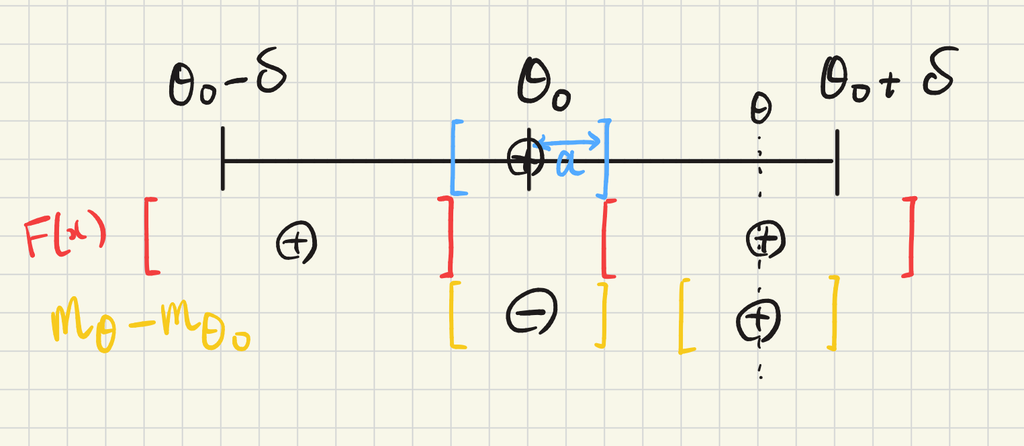

包絡関数の図

包絡関数の $L^2$ ノルムは
$$\|F\|_{P,2}^2
=\int_{\theta_0-a-\delta}^{\theta_0-a+\delta}p(x)\,\mathrm{d}x
+\int_{\theta_0+a-\delta}^{\theta_0+a+\delta}p(x)\,\mathrm{d}x
\leq\|p\|_{\infty}4\delta.$$
と評価できるので，Van der Vaart (1998) Corollary 19.35 より，
$$\E_P\left[\sup_{|\theta-\theta_0|\leq\delta}|\G_n(m_\theta-m_{\theta_0})|\right]\lesssim\|F\|_{P,2}\int_{0}^{1}\sqrt{\log N_{[]}(\varepsilon\|F\|_{P,2},\mathcal{F}_\delta,L^2(P))}\,\mathrm{d}\varepsilon.$$

残った積分項は $\|F\|_{P,2}$ に依らない形で上から抑えることができる（らしい）．

**Note**

たぶん，VC 次元が有限であることを使って殴るんだと思います…

**Memo**

おそらく，Chernoff Mode Estimator と呼ばれる推定量．Chernoff (1964) を参照． $a$ を $n$ に依存するように選ぶと収束レートが変わるみたいなことにも言及している．

# 付録

## 外期待値，外確率に関するあれこれ

**Definition 1 (外期待値)** 関数 $T\colon\Omega\to\overline\R$ の外期待値とは，
$$\E^\star[T]\coloneqq\inf\{\E[U]\mid U\colon\Omega\to\overline\R\text{ は可測で期待値が存在},U\geq T\}.$$

**Memo**

定義より，$T$ が可測なら，$\E^\star[T]=\E[T]$.

**Definition 2 (外確率)** 集合 $A\subset\Omega$ の外確率とは，
$$\Pr^\star(A)\coloneqq\inf\{\Pr(B)\mid B\subset\Omega\text{ は可測で }A\subset B\}.$$

**Memo**

$\Pr^\star(A)=\E^\star[1_A]$ が成り立つ．Van der Vaart and Wellner (2023) Lemma 1.2.3 を参照．

**Proposition 4 (外期待値の単調性)** $T_i\colon\Omega\to\overline\R\,(i=1,2)$ に対して，$T_1\geq T_2$ ならば，$\E^\star[T_1]\geq\E^\star[T_2]$.

**Proposition 5 (外確率の劣加法性)** $A,A_n\subset\Omega$ に対して，$A\subset\bigcup_{n\in\mathbb{N}}A_n$ ならば， $\Pr^\star(A)\leq\sum_{n\in\mathbb{N}}\Pr^\star(A_n)$.

*Proof*. $\varepsilon>0$ を任意に固定する． $A_n$ に対し，$A_n\subset B_n$ かつ $\Pr(B_n)\leq\Pr^\star(A_n)+\varepsilon/2^n$ を満たす可測集合 $B_n$ が選べる．
$$\Pr^\star(A)\leq\Pr\left(\bigcup_{n\in\mathbb{N}}B_n\right)
\leq\sum_{n\in\mathbb{N}}\left(\Pr^\star(A_n)+\varepsilon/2^n\right)
\leq\sum_{n\in\mathbb{N}}\Pr^\star(A_n)+\varepsilon.$$

$\varepsilon\searrow0$ とすればよい．

**Proposition 6 (Markov の不等式)** $T\colon\Omega\to[0,\infty]$ とする．このとき，任意の $x>0$ に対して，
$$\Pr^\star(T>x)\leq\frac{\E^\star[T]}{x}.$$

*Proof*. 任意の $U\geq T$ を満たす $U\colon\Omega\to[0,\infty]$ に対し，Markov の不等式を使うと，
$$\Pr^\star(T>x)\leq\Pr(U>x)\leq\frac{\E[U]}{x}.$$

$U$ に関して下限をとることで，$\Pr^\star(T>x)\leq\E^\star[T]/x$ が得られる．

## References

Chernoff, H. 1964. “Estimation of the Mode.” *Annals of the Institute of Statistical Mathematics* 16 (1): 31–41.

Van der Vaart, A. W. 1998. *Asymptotic Statistics*. 1st ed. Cambridge University Press. https://doi.org/10.1017/CBO9780511802256.

Van der Vaart, A. W., and J. A. Wellner. 2023. *Empirical Processes*. Cham: Springer International Publishing. https://doi.org/10.1007/978-3-031-29040-4_2.